# Ma_ALY6000Project2

Zihan Ma

**ALY6000 Introduction to Analytics**  
**Northeastern University**  
Zihan Ma  
Date: 02 - 18 - 2023

Project Report

```r
# Libraries used in this markdown
library(rmarkdown)
library(readxl)
library(readr)
library(tidyverse)
library(dplyr)
library(knitr)
library(kableExtra)
library(magrittr)
library(RColorBrewer)

# Data imported from M2Project_Data.xlsx
library(readxl)
M2Data <- read_excel("DataSets/M2Project_Data-1.xlsx",
    sheet = "M2Project_V2")
```

Introduction

1. The importance of descriptive and inferential statistics

On Bradley University’s web page, descriptive statistics is included all the population, which means it can minimum the error compare to the reality.

The inferential statistics is doing much better in uncountable, large number population. Which we hare or cannot to use descriptive statistics on it.

2. Importance of proper data presentation

In “Statistical relevance—relevant statistics, part II: presenting experimental data” by Bernd Klaus, he explained that the proper data presentation will strength the evidence of the analysis and publications. They also helps people find out the patterns and difference in your data set.

3. Mention some practical applications of R in data analysis

It easy to find the article that used R to make the chart on Google scholar. For example , the authors use R language to analyse their data in “An Empirical Data Analytics and Visualization for UBER Services: A Data Analysis Based Web Search Engine”. And they used half of their introduction space to explain the advantage to use R for their analyse tool.

Task 1 **Present the first 5 and the last 5 records from the dataset**

```r
first5m2 = head(M2Data, n = 5)
last5m2 = tail(M2Data, n = 5)

firstandlast5m2=rbind(first5m2, last5m2)

kbl(firstandlast5m2) %>%
  kable_styling(bootstrap_options = c("striped", "hover", "condensed", "responsive"))
```

| Region | Market | Company_Segment | Product_Category | Product_SubCategory | Price | Quantity | Sales | Profits | ShippingCost |
| --- | --- | --- | --- | --- | --- | --- | --- | --- | --- |
| Central US | USCA | Consumer | Technology | Phones | 221.98 | 2 | 443.96 | 62.15 | 40.77 |
| Oceania | Asia Pacific | Corporate | Furniture | Chairs | 3709.40 | 9 | 33384.60 | -288.77 | 923.63 |
| Oceania | Asia Pacific | Consumer | Technology | Phones | 5175.17 | 9 | 46576.53 | 919.97 | 915.49 |
| Western Europe | Europe | Home Office | Technology | Phones | 2892.51 | 5 | 14462.55 | -96.54 | 910.16 |
| Western Africa | Africa | Consumer | Technology | Copiers | 2832.96 | 8 | 22663.68 | 311.52 | 903.04 |
| Eastern Asia | Asia Pacific | Consumer | Furniture | Tables | 2614.69 | 7 | 18302.83 | -821.96 | 203.26 |
| Western US | USCA | Corporate | Office Supplies | Appliances | 69.48 | 1 | 69.48 | 20.84 | 12.04 |
| Oceania | Asia Pacific | Consumer | Technology | Copiers | 636.78 | 2 | 1273.56 | 286.50 | 203.20 |
| South America | LATAM | Corporate | Furniture | Bookcases | 2751.20 | 10 | 27512.00 | 110.00 | 203.13 |
| Southeastern Asia | Asia Pacific | Corporate | Technology | Phones | 1587.00 | 3 | 4761.00 | -76.56 | 203.08 |

In the ten observations here, we can see there are huge difference in profits, and there isn’t any obvious rule for these differences, I’m guessing a profit /sales chart could helpful for find out the parents, or we have to need to increase the sample number.

Task 2 **Present a table with all categories of Market and their frequencies**

```r
AllMarket = M2Data[, c('Market')]

AllMarketFrequency = table(AllMarket)

kbl(AllMarketFrequency) %>%
  kable_styling(bootstrap_options = c("striped", "hover", "condensed", "responsive"))
```

| Market | Freq |
| --- | --- |
| Africa | 54 |
| Asia Pacific | 365 |
| Europe | 248 |
| LATAM | 133 |
| USCA | 200 |

The chart here shows the Africa’s frequency is clearly lower than other area’s frequencies. It could be affect by Africa’s economics conduction deeply, which data that need is not include in this data set.

Task 3 **Present a bar graph with all categories of Market and their frequencies**

[figure not shown]

```r
plotAllMarketFrequency = barplot(AllMarketFrequency[order(AllMarketFrequency,decreasing = TRUE)],
                 main="Plot of All Market's Frequency",
                 xlab="Market Frequency",
                 ylab = "Market Name",
                 border = "red",
                 las = 1,
                 cex.axis = 0.6,
                 cex.names = 0.6,
                 horiz = T,
                 legend.text = rownames(AllMarketFrequency),
                 space = 0.5,
                 xlim = c(0,400),
                 col = brewer.pal(8,"Set1")
                 )
text(AllMarketFrequency[order(AllMarketFrequency,decreasing = TRUE)],
     plotAllMarketFrequency,
     AllMarketFrequency[order(AllMarketFrequency,decreasing = TRUE)],
     cex=0.8,
     pos=4)
```

There are almost equally difference between different area frequencies, that tell us we need to keep in mind that we have to treats all group of data differently because they have big number off compare to each other.

Task 4 **Pie chart of product category frequencies in Africa**

[figure not shown]

```r
t4Africa = dplyr::filter(M2Data, Market == "Africa")

Product_Categoryt4Africa = t4Africa[, c('Product_Category')]

Product_Categoryt4AfricaFrequency = table(Product_Categoryt4Africa)

pieLabels = paste(unique(sort(t4Africa$Product_Category)),
                  "\n",
                  round(Product_Categoryt4AfricaFrequency,1),
                  "%")

pie(Product_Categoryt4AfricaFrequency,
    labels = pieLabels,
    radius = 0.6,
    col = terrain.colors(3),
    border = "white",
    lty = 1,
    cex=0.8,
    font = 3
    )


legend("bottomleft",
       legend = paste(unique(sort(t4Africa$Product_Category))),
       fill = terrain.colors(3),
       border = "black")

box(col="red")
```

The plot shows that the major number of companies in Africa is focus on technology area.

Task 5 **Reproduce codes given by instructor**

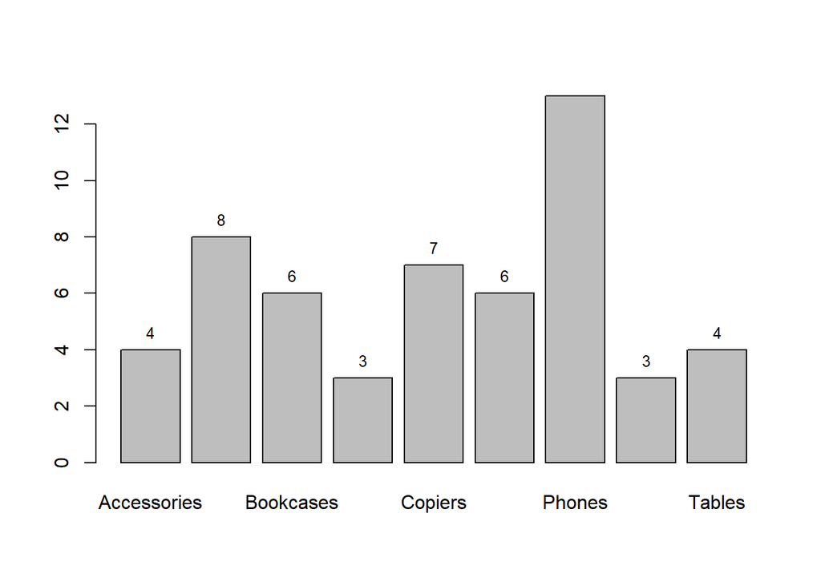

```r
task5_table = table(t4Africa$Product_SubCategory)

t5bar = barplot(task5_table)

text(y=table(t4Africa$Product_SubCategory),
  t5bar,
  table(t4Africa$Product_SubCategory),
  cex=0.8,
  pos=3)
```

The default plot didn’t show all labels properly, it’s hard to provide any correct information from the plot.

Task 6 **Improve bar plot from task 5**

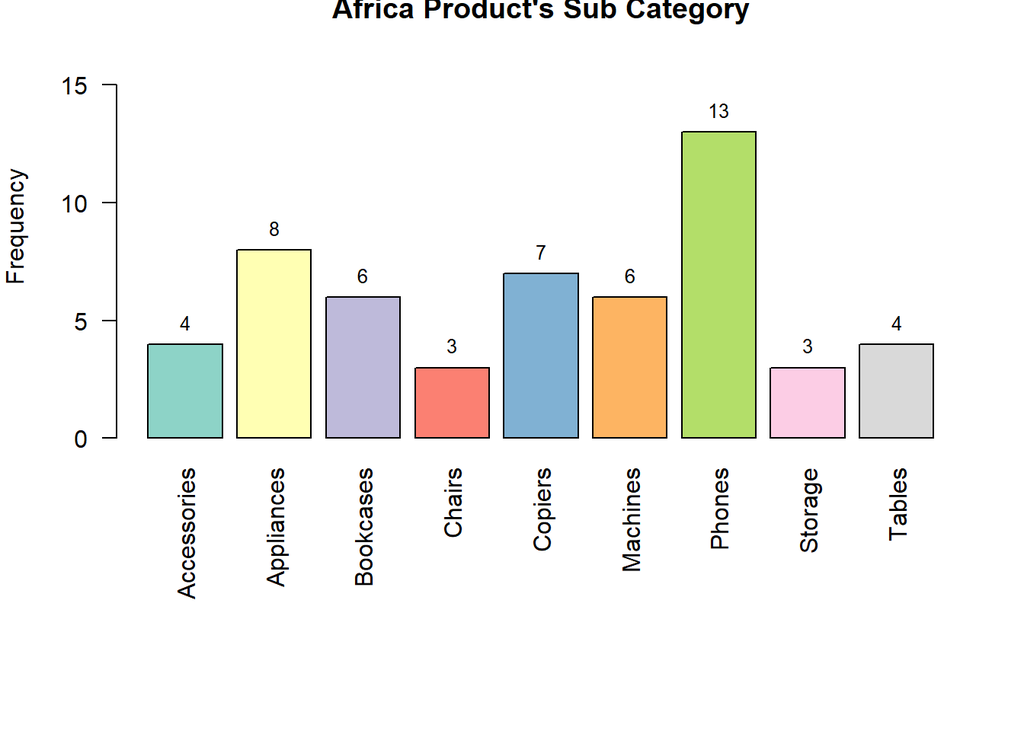

```r
task6_table = table(t4Africa$Product_SubCategory)

par(mar = c(10,4,0.5,2))


#t6bar = barplot(task6_table)


barplot(task6_table,
main = "Africa Product's Sub Category",
las=2,
# xlab = "Category",
ylab = "Frequency",
col = brewer.pal(9, "Set3"),
ylim=c(0,18),
horiz = FALSE)


text(y=table(t4Africa$Product_SubCategory),
  t5bar,
  table(t4Africa$Product_SubCategory),
  cex=0.8,
  pos=3)
```

There are many companies are tiring to sell phones in Africa. Which is technology relative product.

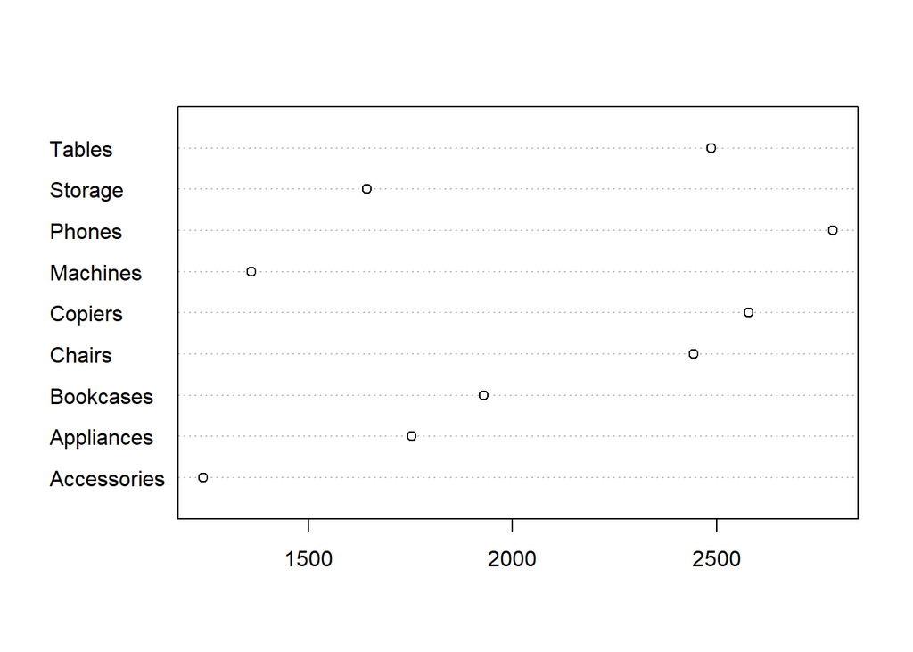

```r
meanSales = tapply(t4Africa$Price, t4Africa$Product_SubCategory, mean)

dotchart(meanSales)
```

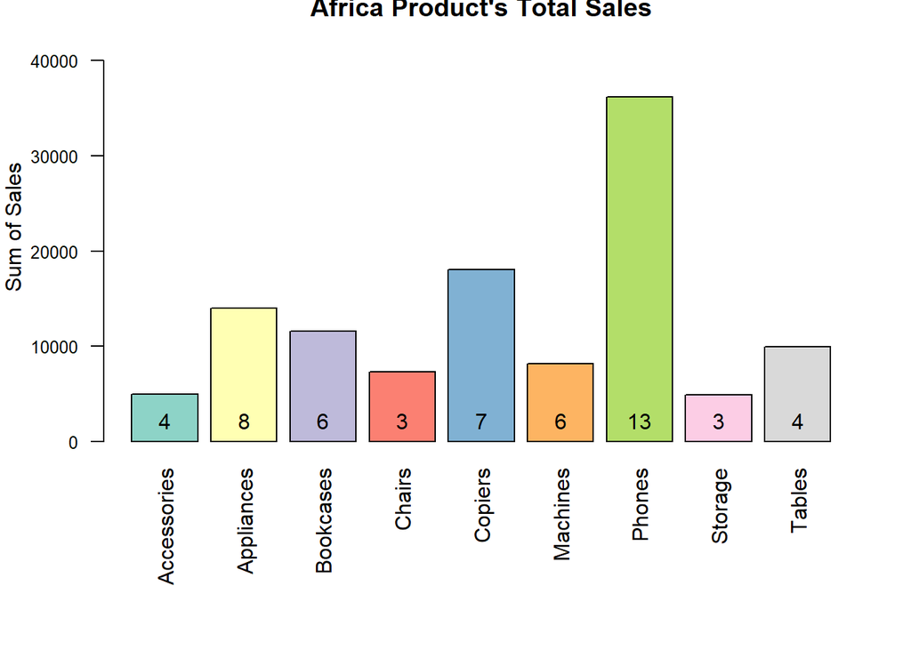

```r
sumSales = tapply(t4Africa$Price, t4Africa$Product_SubCategory, sum)

par(mar = c(8,4,0.5,2))

barplot(sumSales,
main = "Africa Product's Total Sales",
las=2,
# xlab = "Sum of Sales",
ylab = "Sum of Sales",
col = brewer.pal(9, "Set3"),
cex.axis = 0.8,
ylim=c(0,45000),
horiz = FALSE)


text(y=table(t4Africa$Product_SubCategory),
  t5bar,
  table(t4Africa$Product_SubCategory),
  cex=1,
  pos=3)
```

The total sales plot of Africa is very same to Frequency plot we have above in Task 6. That proved these two group could strongly related to each other.

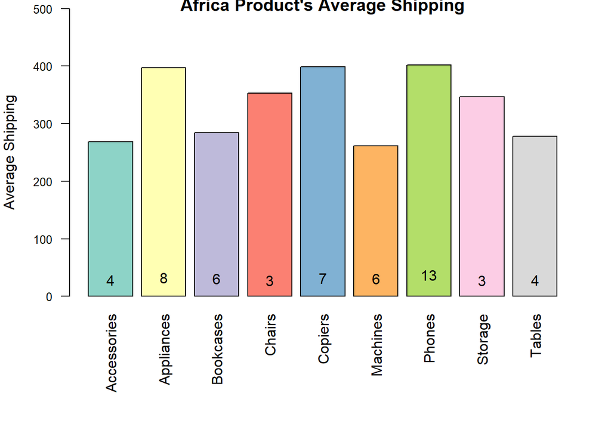

```r
meanShipping = tapply(t4Africa$ShippingCost, t4Africa$Product_SubCategory, mean)

par(mar = c(8,4,0.5,2))

barplot(meanShipping,
main = "Africa Product's Average Shipping",
las=2,
# xlab = "Average Shipping",
ylab = "Average Shipping",
col = brewer.pal(9, "Set3"),
cex.axis = 0.8,
ylim=c(0,500),
horiz = FALSE)


text(y=table(t4Africa$Product_SubCategory),
  t5bar,
  table(t4Africa$Product_SubCategory),
  cex=1,
  pos=3)
```

There isn’t great difference between different shipping price in Africa. This data set might not very valuable for analyics.

Task 10 **Descriptions of: integer, factor, double, numeric**

As the website “R for Health Data Science” said,

“Integers are numbers without decimal places (e.g., 1, 2, 3)”

“Double stands for “Double-precision floating-point” format (e.g., 1.234, 5.67890).”

“The values factor levels can take are fixed, and it have an order.”

“Numbers are”R usually refers to numbers as numeric (or num)”

Task 11 **Duplicate codes presented by instructor**

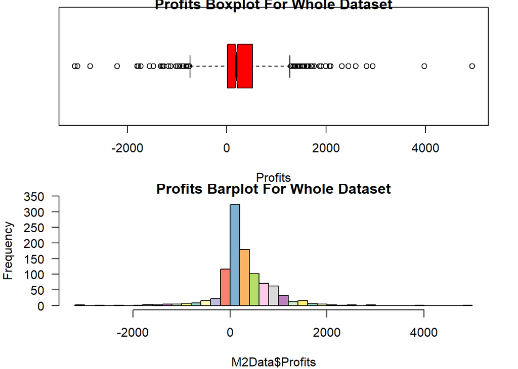

```r
par(mfcol = c(2, 1),
    mai = c(1, 1, 0.2, 0.4),
    mar = c(4, 4, 0.5, 2))



boxplot(M2Data$Profits,
        horizontal = T,
        col = rainbow(ncol(trees)),
        xlab = "Profits" ,
        notch = TRUE,
        main = "Profits Boxplot For Whole Dataset")

hist(M2Data$Profits,
     main = "Profits Barplot For Whole Dataset",
     las=1,
     ylim=c(0,350),
     col = brewer.pal(12, "Set3"),
     breaks = 50)
```

From two plot we can see that there isn’t too much off between profits. Because more then 50% of data in box plot is concentrate at a short range compare to the distribution. In average most compiles are earning money, but not that much.

There are many off point on the box plot, but from bar plot we can know these off points are all ignoble.

Task 12 **Profits in the Latin American market**

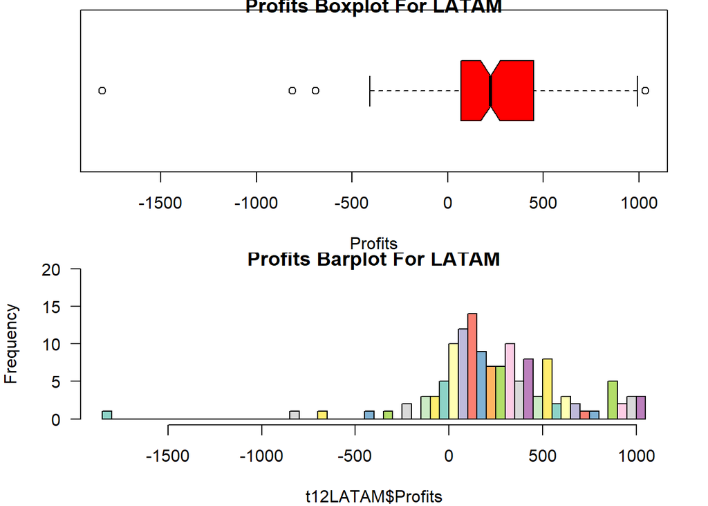

```r
t12LATAM = dplyr::filter(M2Data, Market == "LATAM")

par(mfcol = c(2, 1),
    mai = c(1, 1, 0.2, 0.4),
    mar = c(4, 4, 0.5, 2))

boxplot(t12LATAM$Profits,
        horizontal = T,
        col = rainbow(ncol(trees)),
        xlab = "Profits" ,
        notch = TRUE,
        main = "Profits Boxplot For LATAM")

hist(t12LATAM$Profits,
     main = "Profits Barplot For LATAM",
     las=1,
     ylim=c(0,20),
     col = brewer.pal(12, "Set3"),
     breaks = 50)
```

It’s easy to notice from box plot, more than 50% companies are earning money in Latin America.

And there is only three companies are loosing money greatly(>=500).

```r
t13LATAM =dplyr::filter(M2Data, Market == "LATAM")
sumLATAMSales = tapply(t13LATAM$Price, t13LATAM$Product_SubCategory, sum)

kbl(sumLATAMSales) %>%
  kable_styling(bootstrap_options = c("striped", "hover", "condensed", "responsive"))
```

|  | x |
| --- | --- |
| Accessories | 4212.04 |
| Appliances | 46953.82 |
| Bookcases | 22828.15 |
| Chairs | 28720.25 |
| Copiers | 19571.01 |
| Machines | 533.22 |
| Phones | 78028.52 |
| Storage | 1455.08 |
| Tables | 33961.40 |

Same to the Africa, Latin America people is also spend a lot of money on buying phones.

Task 14 **Box plot for the profits per region in the Latin American market**

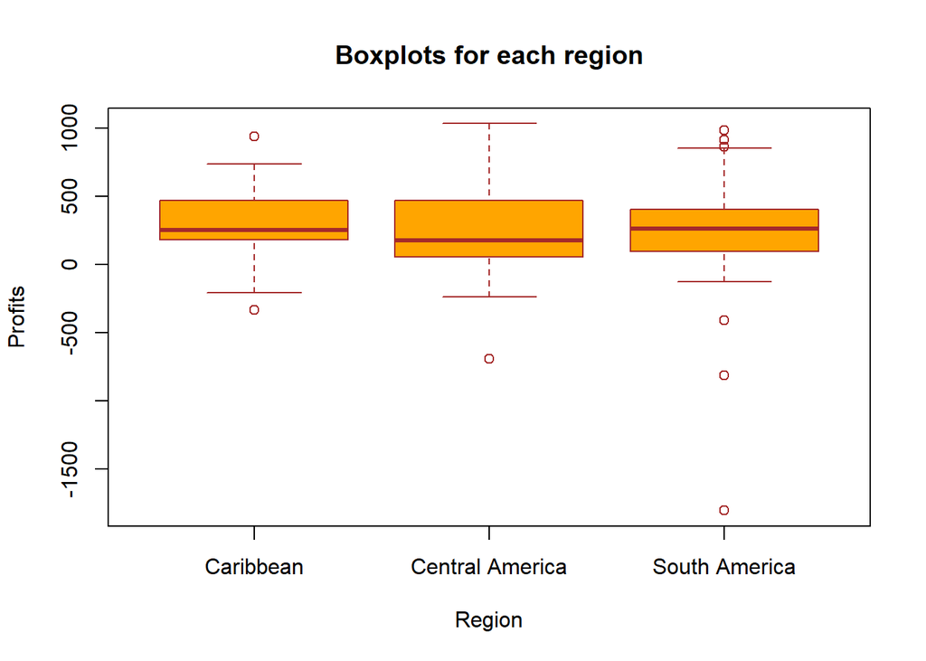

```r
boxplot(Profits~Region,
data=t13LATAM,
main="Boxplots for each region",
xlab="Region",
ylab="Profits",
col="orange",
border="brown"
)
```

From the 3 regions in the Latin American, we can see that their distribution are very same to each other. That means Latin American market doesn’t not have obvious region differences.

Task 15 **Table with cumulative frequencies and probabilities**

```r
t15 = M2Data$Product_SubCategory%>%
  table() %>%
  as.data.frame()%>%
  rename(Frequencies = Freq)%>%
  mutate(CumulativeFrequency = cumsum(Frequencies),
         Probability = Frequencies/nrow(M2Data),
         CumulativeProbability = cumsum(Probability))

knitr::kable(t15,
             digits = 2,
             caption = "Table with cumulative frequencies and probabilities for all region's Product subcategory",
             fomat = "html",
             table.attr = "style='width:40%;'",
             align = 'c') %>%
  kable_classic(bootstrap_option = "striped",
                full_width = TRUE,
                position = "center",
                font_size = 12)
```

Table with cumulative frequencies and probabilities for all region’s Product subcategory

| . | Frequencies | CumulativeFrequency | Probability | CumulativeProbability |
| --- | --- | --- | --- | --- |
| Accessories | 38 | 38 | 0.04 | 0.04 |
| Appliances | 125 | 163 | 0.12 | 0.16 |
| Art | 18 | 181 | 0.02 | 0.18 |
| Binders | 38 | 219 | 0.04 | 0.22 |
| Bookcases | 130 | 349 | 0.13 | 0.35 |
| Chairs | 95 | 444 | 0.10 | 0.44 |
| Copiers | 126 | 570 | 0.13 | 0.57 |
| Envelopes | 2 | 572 | 0.00 | 0.57 |
| Fasteners | 6 | 578 | 0.01 | 0.58 |
| Furnishings | 14 | 592 | 0.01 | 0.59 |
| Labels | 6 | 598 | 0.01 | 0.60 |
| Machines | 52 | 650 | 0.05 | 0.65 |
| Paper | 32 | 682 | 0.03 | 0.68 |
| Phones | 179 | 861 | 0.18 | 0.86 |
| Storage | 45 | 906 | 0.04 | 0.91 |
| Supplies | 7 | 913 | 0.01 | 0.91 |
| Tables | 87 | 1000 | 0.09 | 1.00 |

Both Cumulative Frequency and Cumulative Probability are adding to the 1000/1.00 at the end. Which means there isn’t missing observations.

Task 16 **Probability graphs**

[figure not shown]

```r
AllMarketFrequency = table(AllMarket)

par(mfrow=c(2,2),mar = c(8, 8, 0.5, 2), mai = c(1,1,0.5,0.2))


Product_Category = M2Data[, c('Product_Category')]
Product_CategorFrequency = table(Product_Category)

pieLabels = paste(M2Data$Product_Category,
                  round(100*Product_CategorFrequency/sum(Product_CategorFrequency), 1)
                  , "%")

pie(t15$Frequencies,
    labels = pieLabels,
    main = "Frequency",
    radius = 1.1,
    col = terrain.colors(17),
    border = "black",
    lty = 1,
    cex=0.4,
    font = 3
    )


barplot(t15$CumulativeFrequency,
main = "Cumulative Frequency",
las=2,
names.arg=c(t15$.),
# xlab = "Average Shipping",
ylab = "Frequency",
col = brewer.pal(12, "Set3"),
cex.axis = 0.6,
cex.lab = 0.6,
cex.names = 0.6,
ylim=c(0,1200),
horiz = FALSE)





pie(t15$Probability,
    labels = pieLabels,
    main = "Probability",
    radius = 1.1,
    col = terrain.colors(17),
    border = "black",
    lty = 1,
    cex=0.4,
    font = 3
    )


barplot(t15$CumulativeProbability,
main = "Cumulative Probability",
las=2,
names.arg=c(t15$.),
# xlab = "Average Shipping",
ylab = "Probability",
col = brewer.pal(12, "Set3"),
cex.axis = 0.6,
cex.lab = 0.6,
cex.names = 0.6,
ylim=c(0,1),
horiz = FALSE)
```

From plots we can see 1/3 of total Product Category have very little effect to the tatal sample, which have very little area in the pie plot.

Task 17 **Free graph**

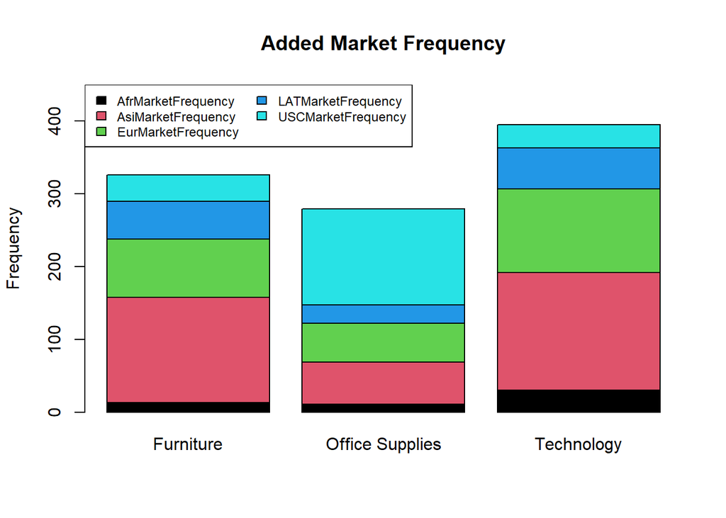

```r
Africa = dplyr::filter(M2Data, Market == "Africa")
AsiaPacific = dplyr::filter(M2Data, Market == "Asia Pacific")
Europe = dplyr::filter(M2Data, Market == "Europe")
LATAM = dplyr::filter(M2Data, Market == "LATAM")
USCA = dplyr::filter(M2Data, Market == "USCA")

AfrMarketFrequency = table(Africa$Product_Category)
AsiMarketFrequency = table(AsiaPacific$Product_Category)
EurMarketFrequency = table(Europe$Product_Category)
LATMarketFrequency = table(LATAM$Product_Category)
USCMarketFrequency = table(USCA$Product_Category)




AddedMarketFrequency=rbind(AfrMarketFrequency, AsiMarketFrequency, EurMarketFrequency, LATMarketFrequency, USCMarketFrequency)

barplot(AddedMarketFrequency,
main = "Added Market Frequency",
#names.arg=c(t15$.),
# xlab = "Average Shipping",
ylab = "Frequency",
col = 1:5,
cex.axis = 1,
cex.lab = 1,
cex.names = 1,
ylim=c(0,450),
horiz = FALSE)

legend("topleft",
       legend = rownames(AddedMarketFrequency),
       fill = 1:5, ncol = 2,
       cex = 0.75)
```

Here is the plot that shows the frequency construction for each region for each Product Category. I believe it can shows the data more directlly.

Conclusions **Present**

1. I learned a lot from this project, especially for give out a good looking format for different plots such as box plot and bar plot. Also It’s important to learn using dplyr::filter() to extract a part from the source data frame as a table very easily.
2. By observe this project, we can easily knows that what is the most money earning products, and the product with list risk. From those observations, we can gives out the advice that technology or phones is selling well in most region in the worlds wide.
3. If I’m working on write a good report, I will try to get more recent data set, which will make my report affect less by any timely or random economics events.

Bibliography

Descriptive statistics vs. inferential statistics. Bradley University Online. (2022, March 9). Retrieved January 30, 2023, from https://onlinedegrees.bradley.edu/blog/whats-the-difference-between-descriptive-and-inferential-statistics/

Klaus, B. (2016). Statistical relevance—relevant statistics, part ii : Presenting experimental data. The EMBO Journal, 35(16), 1726–1729. https://doi.org/10.15252/embj.201694659

Pius, E. H. and R. (2021, January 15). R for Health Data Science. 2.2 Variable types and why we care. Retrieved January 30, 2023, from https://argoshare.is.ed.ac.uk/healthyr_book/chap02-vartypes.html

Sudar, K.(1970, January 1). An empirical data analytics and visualization for uber services: A data analysis based web search engine: Semantic scholar. 2022 International Conference on Computer Communication and Informatics (ICCCI). Retrieved January 30, 2023, from https://www.semanticscholar.org/paper/An-Empirical-Data-Analytics-and-Visualization-for-A-Sudar-Nagaraj/771b059c9ca9a7799ab2b19cd5ba7a83129aa218

Appendix

An R Markdown file has been attached to this report. The name of the file is “Ma_ALY6000Project2..Rmd”